# Getting started with GGPlot2

EdinbR 18/03/2015

## Why learn GGPlot2?

- Prettier plots
- A systematic way of manipulating data, esp. when combined with `dplyr`. Better than relying on a collection of recipes.

## GGplot2:

- GG stands for Grammar of Graphics (Wilkinson, 2005).
- Provides a unified, statistically-oriented approach to graphical representation.
- Does so thanks to the use of more abstract objects than just raw graphical elements.

## Using `ggplot2`

`ggplot2` offers at least three ways for producing plots, varying in verbosity:

- `qplot`
- `ggplot+geom_xxx`
- `ggplot+layer`

Today, we'll focus on `ggplot+geom` because it's verbose enough to make the workings of `ggplot2` transparent and readable.

## A first example 1/2

- Dataset to use: `diamonds`. `?diamonds` gives a short description of the data.
- We'll use a subset of the whole dataset:

```r
    set.seed(42)
    small <- diamonds[sample(nrow(diamonds),1000),]
```

- A quick peek at the data:

```
##       carat       cut color clarity depth table price    x    y    z
## 49345  0.71 Very Good     H     SI1  62.5    60  2096 5.68 5.75 3.57
## 50545  0.79   Premium     H     SI1  61.8    59  2275 5.97 5.91 3.67
## 15434  1.03     Ideal     F     SI1  62.4    57  6178 6.48 6.44 4.03
## 44792  0.50     Ideal     E     VS2  62.2    54  1624 5.08 5.11 3.17
## 34614  0.27     Ideal     E     VS1  61.6    56   470 4.14 4.17 2.56
## 27998  0.30   Premium     E     VS2  61.7    58   658 4.32 4.34 2.67
```

## A first example 2/2

A first look at the relation between `carat` and `price`:

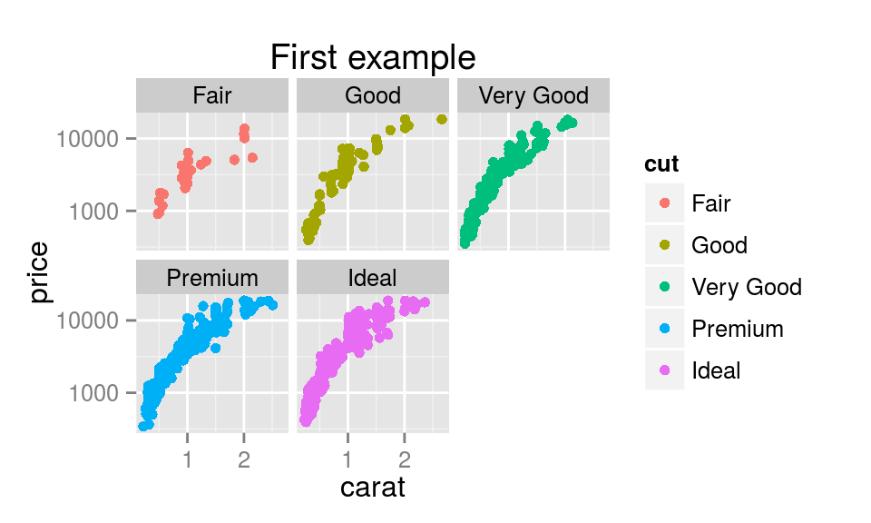

```r
ggplot(small) +
  geom_point(aes(x=carat,y=price,colour=cut)) +
    scale_y_log10() +
            facet_wrap(~cut) +
                ggtitle("First example")
```

## Let's decompose the `ggplot2` command.

### Data

Create the ggplot object and populate it with data (always a data frame)

```r
ggplot(small)
```

### Layers

Add layer(s)

```r
geom_point(aes(x=carat,y=price,colour=cut))
```

## Let's decompose the `ggplot2` command.

### [facets]

Used for conditionning on variable(s)

```r
facet_wrap(~cut)
```

### [scales]

Scales for dimensions, colour palettes etc.

```r
scale_y_log10()
```

### [more options]

```r
ggtitle("First example")
```

## Mapping aesthetics

All `geom_xxx()` require some *aesthetics*. `?geom_point`

```
> (...)
> Aesthetics
> The following aesthetics can be used with geom_point. Aesthetics are mapped
> to variables in the data with the aes function: geom_point(aes(x = var))
> x: x position (required)
> y: y position (required)
> shape: shape of point
> colour: border colour
> size: size
> fill: internal colour
> alpha: transparency
```

Thus:

```r
ggplot(small)+geom_point(aes(x=carat,y=price,colour=cut))
```

also possible:

```r
ggplot(small,aes(x=carat,y=price,colour=cut))+geom_point()
```

```r
ggplot(small,aes(x=carat,y=price))+geom_point(aes(colour=cut))
```

## A subtlety to be aware of

Caveat: there is a difference between *setting* and *assigning* aesthetics.

```r
p <- ggplot(small)
```

**Assigning** (or mapping) is done through `aes`.

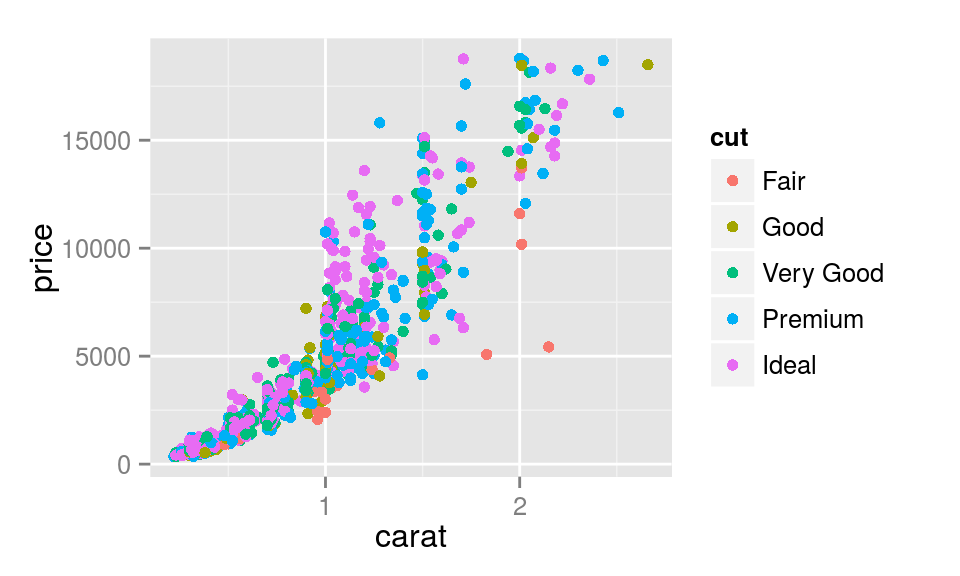

```r
p + geom_point(aes(x = carat, y = price, colour = cut))
```

## A subtlety to be aware of

Caveat: there is a difference between *setting* and *assigning* aesthetics.

**Assigning**: Done through `aes`.

```r
p + geom_point(aes(x = carat, y = price, colour = cut))
```

**Setting**: Fixes a parameter to a certain value and is done *outside* `aes`

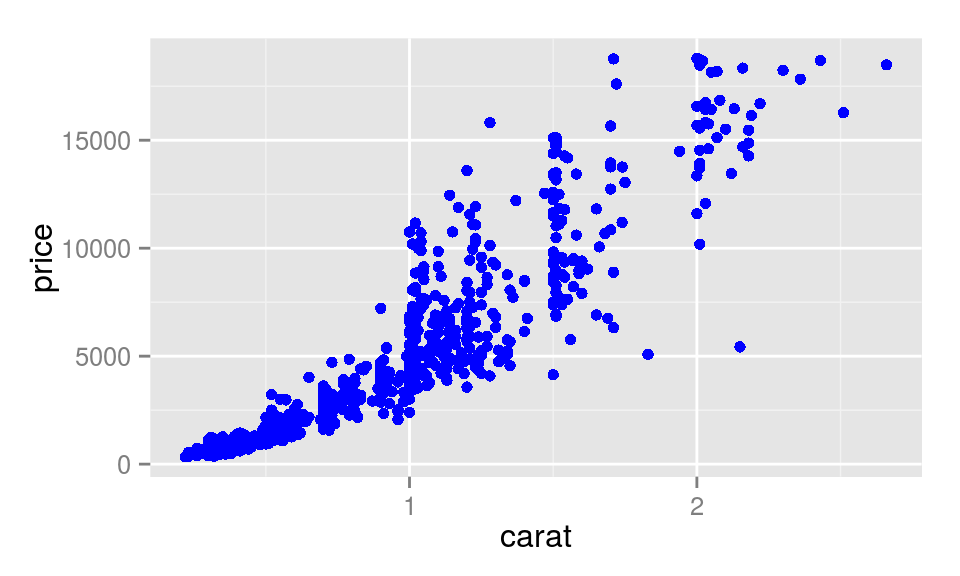

```r
p + geom_point( aes( x  = carat, y = price), colour = "blue")
```

## A subtlety to be aware of

Caveat: there is a difference between *setting* and *assigning* aesthetics.

### Don't mix

But trying to set an aesthetics in `aes` produces unwanted results:

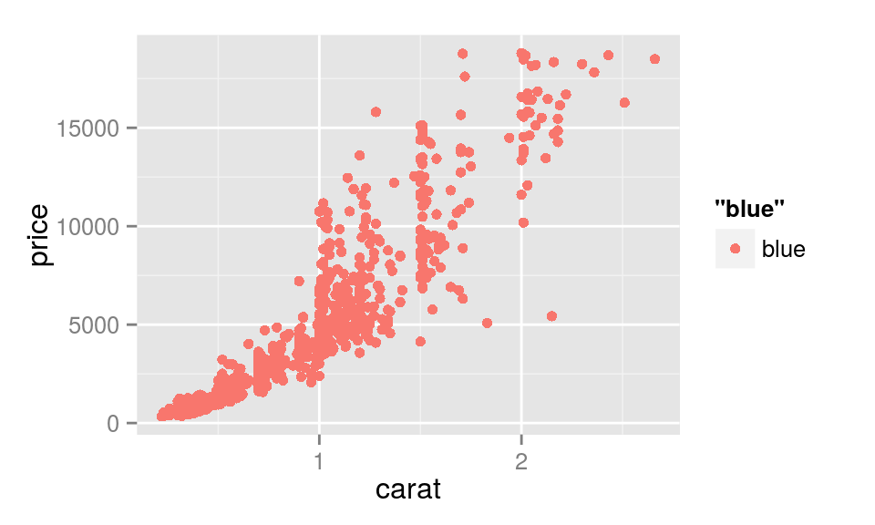

```r
p + geom_point( aes( x = carat, y = price, colour = "blue"))
```

## Faceting

`facet_xxx` are used for conditionning plots on 1 or 2 variables.

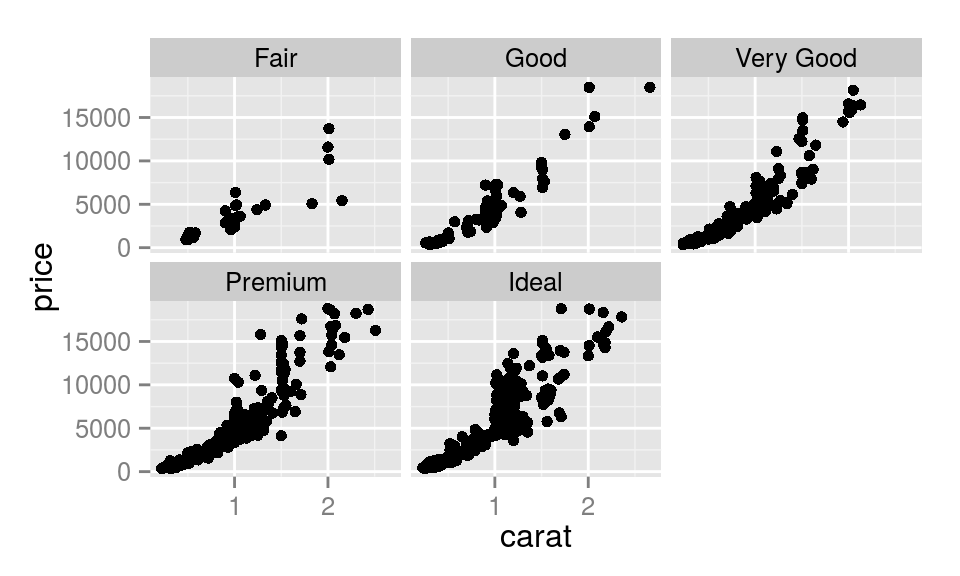

```r
p + geom_point(aes(x=carat,y=price))+facet_wrap(~cut)
```

```r
p+geom_point(aes(x=carat,y=price))+facet_wrap(~cut,nrow=1)
```

```r
p+geom_point(aes(x=carat,y=price))+facet_grid(cut~color)
```

## Faceting

`facet_xxx` are used for conditionning plots on 1 or 2 variables.

```r
p + geom_point(aes(x=carat,y=price))+facet_wrap(~cut)
```

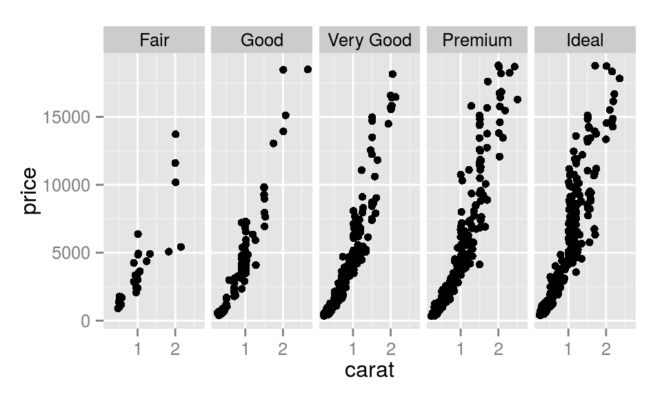

```r
p+geom_point(aes(x=carat,y=price))+facet_wrap(~cut,nrow=1)
```

```r
p+geom_point(aes(x=carat,y=price))+facet_grid(cut~color)
```

## Faceting

`facet_xxx` are used for conditionning plots on 1 or 2 variables.

```r
p + geom_point(aes(x=carat,y=price))+facet_wrap(~cut)
```

```r
p+geom_point(aes(x=carat,y=price))+facet_wrap(~cut,nrow=1)
```

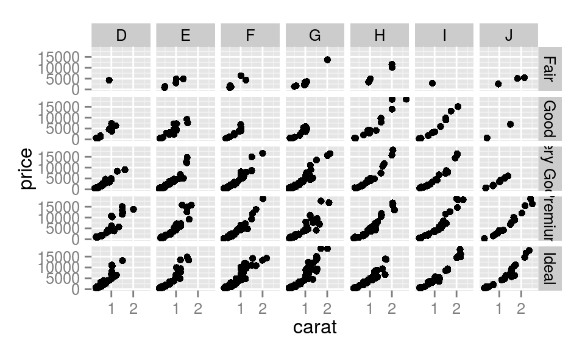

```r
p+geom_point(aes(x=carat,y=price))+facet_grid(cut~color)
```

## Fitting models with `geom_smooth`

`geom_smooth` is useful for displaying a trend in the data.

```r
p <- ggplot(small,aes(x = carat, y = price)) + geom_point()
```

By default, `geom_smooth` uses loess (akin to splines), or gam (generalised additive models) for larger datasets.

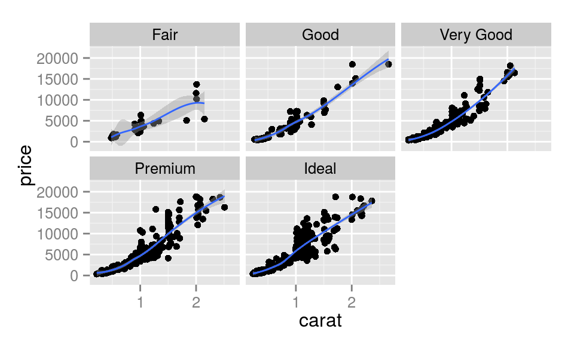

```r
p  + geom_smooth() + facet_wrap( ~ cut)
```

## Fitting models with `geom_smooth`

You can also specify a function to use:

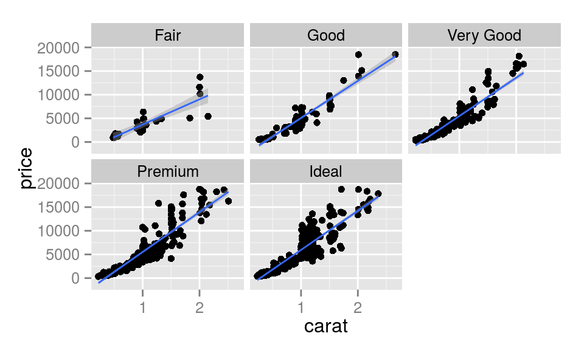

```r
p  + geom_smooth( method = "lm") + facet_wrap( ~ cut)
```

## Putting everything together

Linear relation between `carat` and `price`, for each type of `cut`, on a log-log scale:

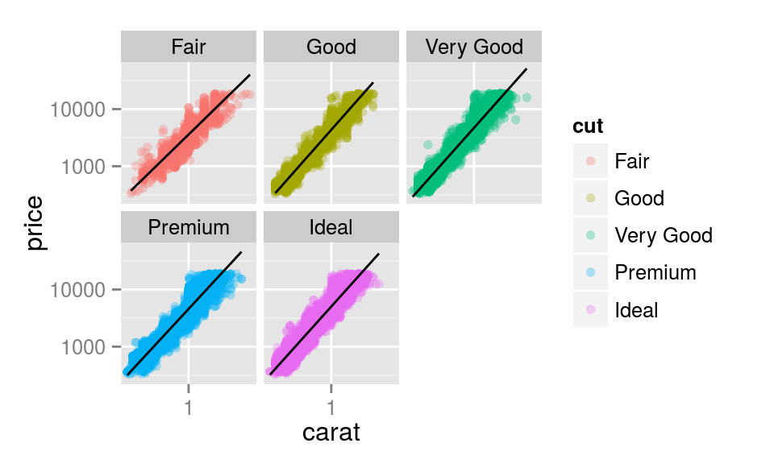

```r
ggplot(diamonds, aes( x = carat, y = price, colour = cut)) +
  scale_x_log10() + scale_y_log10() +
    geom_point( alpha = 0.3) +
      geom_smooth(method = "lm", colour = 'black') +
        facet_wrap( ~ cut)
```

## Many other geoms available

They all work on the same principle: mapping/setting aesthetics.

```
geom_abline         geom_jitter
geom_area           geom_line
geom_bar            geom_linerange
geom_bin2d          geom_path
geom_blank          geom_point
geom_boxplot        geom_pointrange
geom_contour        geom_polygon
geom_crossbar       geom_quantile
geom_density        geom_rect
geom_density2d      geom_ribbon
geom_errorbar       geom_rug
geom_errorbarh      geom_segment
geom_freqpoly       geom_smooth
geom_hex            geom_step
geom_histogram      geom_text
geom_hline          geom_tile
geom_vline          etc.
```

## A couple of tricks

- Ordering elements
- Using `aes` programmatically

## Ordering elements

`wikipedia` contains the number of articles in the top 6 contributing languages. We use a bar plot to compare them.

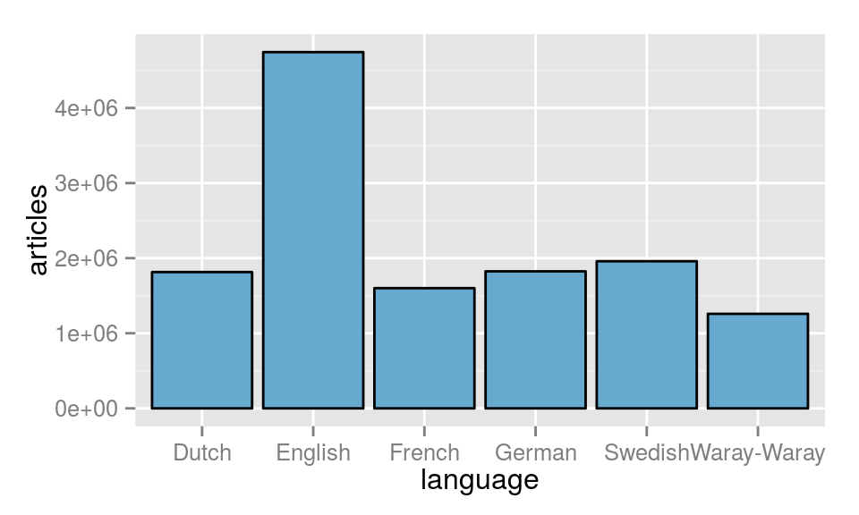

```r
wikipedia <- data.frame(
  language = c( "English", "Swedish", "German", "Dutch", "French", "Waray-Waray"),
  articles = c(   4743614,  1959101,   1824951, 1814795,  1600497,       1259079))

ggplot(wikipedia) +
  geom_bar(aes(x=language, y=articles), fill="#67a9cf", colour="black", stat="identity")
```

## Ordering elements

`wikipedia` contains the number of articles in the top 6 contributing languages. We use a bar plot to compare them.

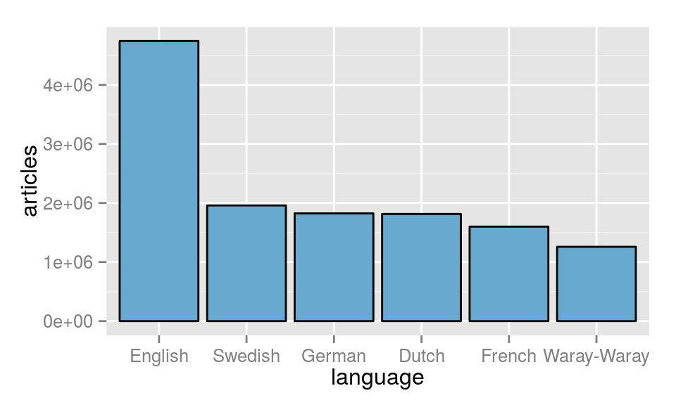

```r
wikipedia$language <- reorder(wikipedia$language, -wikipedia$articles)

ggplot(wikipedia) +
  geom_bar(aes(x=language, y=articles), fill="#67a9cf", colour="black", stat="identity")
```

## Using `aes` programmatically

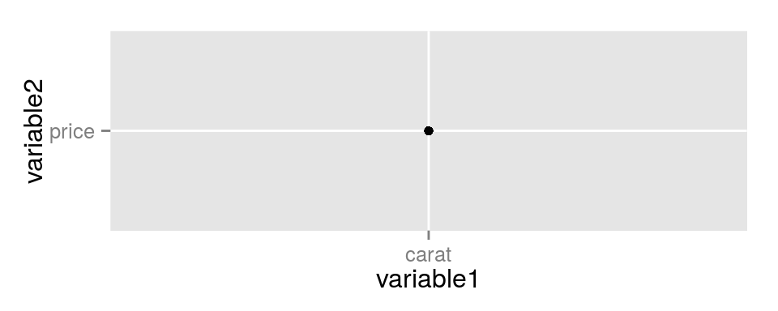

```r
variable1 <- 'carat'; variable2 <- 'price'
ggplot(small) + geom_point(aes(x = variable1, y = variable2))
```

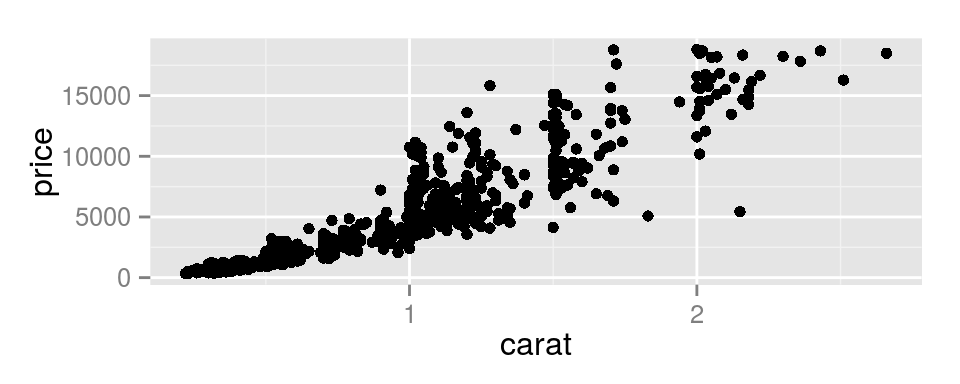

```r
ggplot(small) + geom_point(aes_string(x = variable1, y = variable2))
```

## Good and free resources for ggplot2

- GGplot2 is vast. Not mentioned here: stats, saving as png,pdf etc., scales, themes, geographical maps etc.
- Hadley Wickham's *new* book: https://github.com/hadley/ggplot2-book
- GGplot2 dedicated website: http://docs.ggplot2.org/current/
- Many tutorials on the web, for example: http://r-bloggers.com/tag/ggplot2
- R cookbook: http://www.cookbook-r.com (*e.g.* multiple plots in one figure)
- Recent 1 hour video intro to ggplot2: https://github.com/Myfanwy/ggplot2Intro
- For data manipulation in particular: `dplyr`